# R Notebook

```python
reticulate::repl_python()
import pandas as pd
from pyprojroot import here
```

```r
quit
library(reticulate)
library(tidyverse)
# py_install("pandas-profiling")
# py_install("scikit-learn")
# py_install("scikit-plot")
# py_install("matplotlib")
```

```python
reticulate::repl_python()
# model packages
import pandas_profiling
```

```python
# read in mortality data
hb_mortality = pd.read_csv(here("raw_data/stroke_mortalitybyhbr.csv"))
ca_mortality = pd.read_csv(here("raw_data/stroke_mortalitybyca.csv"))
```

```r
quit
hb_mortality <- py$hb_mortality %>%
  janitor::clean_names()
```

```python
reticulate::repl_python()
# clean data by removing unnecessary columns and values
hb_mortality_reduced = r.hb_mortality.drop(columns = ['hbrqf', 'age_group_qf', 'sex_qf', 'number_of_deaths_qf', 'crude_rate_qf'])

hb_mortality_reduced = hb_mortality_reduced.query('age_group != "All" & sex != "All" & hbr != "S92000003"').dropna()
```

```python
# assign categorical vars dummies
hb_mortality_reduced = pd.get_dummies(hb_mortality_reduced, drop_first = True)

hb_mortality_reduced.head()
```

```
     year  ...  diagnosis_Subarachnoid Haemorrhage
0  2011.0  ...                                   0
1  2011.0  ...                                   0
2  2011.0  ...                                   0
3  2011.0  ...                                   0
4  2011.0  ...                                   0

[5 rows x 24 columns]
```

```python
# set our response array
response_var = hb_mortality_reduced['number_of_deaths']
# put our predictors in a data frame
predictor_vars = hb_mortality_reduced.drop(columns = 'number_of_deaths')
```

```python
# create train / test split
from sklearn.model_selection import train_test_split

mortality_pred_train, mortality_pred_test, mortality_resp_train, mortality_resp_test = (
    train_test_split(
        predictor_vars,
        response_var,
        test_size = 0.1
    )
)
```

```python
# define model using train data
from sklearn.linear_model import LinearRegression
mortality_model = LinearRegression()

mortality_model.fit(mortality_pred_train, mortality_resp_train)
```

```
LinearRegression()
```

```python
# check r-squared value of current model
from sklearn.model_selection import cross_val_score
mortality_model.score(mortality_pred_train, mortality_resp_train)
```

```
0.7829047178190378
```

```python
# r-squared scores for each fold
scores = cross_val_score(
    mortality_model, mortality_pred_train, mortality_resp_train, scoring='r2', cv=10
)
scores
```

```
array([0.84605846, 0.82513548, 0.7010036 , 0.75236915, 0.71547105,
       0.81643191, 0.78184989, 0.76654557, 0.75048785, 0.86216324])
```

```python
import numpy as np

print(mortality_model.score(mortality_pred_train, mortality_resp_train))
```

```
0.7829047178190378
```

```python
# mean score of all models
print(np.mean(scores))
```

```
0.781751620861048
```

```python
# feature importance by matching predictors to coefficients in a df
pd.DataFrame({
    'Variable':predictor_vars.columns,
    'Coefficients':mortality_model.coef_
})
```

```
                              Variable  Coefficients
0                                 year      0.016214
1                           crude_rate      0.647062
2                                 easr     -0.442889
3                        hbr_S08000016    -15.486421
4                        hbr_S08000017    -11.623335
5                        hbr_S08000019     -6.097861
6                        hbr_S08000020      5.061944
7                        hbr_S08000022     -3.565189
8                        hbr_S08000024     14.888184
9                        hbr_S08000025     -1.666681
10                       hbr_S08000026     -2.103581
11                       hbr_S08000028     -1.282732
12                       hbr_S08000029     -2.897635
13                       hbr_S08000030      0.145122
14                       hbr_S08000031     34.932817
15                       hbr_S08000032     12.123173
16               age_group_45-64 years      3.731505
17               age_group_65-74 years      1.641653
18              age_group_75plus years      4.806263
19             age_group_under75 years     16.732905
20                           sex_Males      0.261439
21                    diagnosis_Stroke     -6.150485
22  diagnosis_Subarachnoid Haemorrhage    -10.462776
```

```python
import statsmodels.api as sm

# add in the constant to the data
predictor_vars = sm.add_constant(predictor_vars)
predictor_vars.head()
```

```
   const    year  ...  diagnosis_Stroke  diagnosis_Subarachnoid Haemorrhage
0    1.0  2011.0  ...                 0                                   0
1    1.0  2011.0  ...                 0                                   0
2    1.0  2011.0  ...                 0                                   0
3    1.0  2011.0  ...                 0                                   0
4    1.0  2011.0  ...                 0                                   0

[5 rows x 24 columns]
```

```python
# model summary using statsmodels
sm_model = sm.OLS(response_var, predictor_vars).fit()
print(sm_model.summary())
```

```
                            OLS Regression Results
==============================================================================
Dep. Variable:       number_of_deaths   R-squared:                       0.791
Model:                            OLS   Adj. R-squared:                  0.790
Method:                 Least Squares   F-statistic:                     625.5
Date:                Tue, 07 Jun 2022   Prob (F-statistic):               0.00
Time:                        08:50:07   Log-Likelihood:                -17032.
No. Observations:                3822   AIC:                         3.411e+04
Df Residuals:                    3798   BIC:                         3.426e+04
Df Model:                          23
Covariance Type:            nonrobust
======================================================================================================
                                         coef    std err          t      P>|t|      [0.025      0.975]
------------------------------------------------------------------------------------------------------
const                                  6.6838    238.421      0.028      0.978    -460.762     474.130
year                                  -0.0010      0.118     -0.009      0.993      -0.233       0.231
crude_rate                             0.6503      0.021     31.693      0.000       0.610       0.691
easr                                  -0.4464      0.020    -22.655      0.000      -0.485      -0.408
hbr_S08000016                        -14.4772      1.708     -8.476      0.000     -17.826     -11.128
hbr_S08000017                        -11.8179      1.708     -6.919      0.000     -15.167      -8.469
hbr_S08000019                         -6.4427      1.708     -3.772      0.000      -9.791      -3.094
hbr_S08000020                          5.0986      1.708      2.984      0.003       1.749       8.448
hbr_S08000022                         -3.9127      1.708     -2.290      0.022      -7.262      -0.564
hbr_S08000024                         14.3660      1.709      8.406      0.000      11.015      17.717
hbr_S08000025                         -2.0368      1.990     -1.023      0.306      -5.939       1.866
hbr_S08000026                         -2.3884      1.953     -1.223      0.221      -6.218       1.441
hbr_S08000028                         -1.3549      2.084     -0.650      0.516      -5.440       2.730
hbr_S08000029                         -2.9253      1.708     -1.712      0.087      -6.274       0.424
hbr_S08000030                         -0.1706      1.709     -0.100      0.921      -3.522       3.181
hbr_S08000031                         34.5084      1.708     20.202      0.000      31.159      37.857
hbr_S08000032                         12.2251      1.708      7.157      0.000       8.876      15.574
age_group_45-64 years                  3.7957      1.044      3.635      0.000       1.748       5.843
age_group_65-74 years                  1.6121      1.060      1.521      0.128      -0.466       3.690
age_group_75plus years                 4.6382      1.469      3.158      0.002       1.758       7.518
age_group_under75 years               16.9692      1.066     15.920      0.000      14.879      19.059
sex_Males                              0.4400      0.708      0.622      0.534      -0.948       1.828
diagnosis_Stroke                      -6.1174      0.866     -7.060      0.000      -7.816      -4.419
diagnosis_Subarachnoid Haemorrhage   -10.3423      0.943    -10.970      0.000     -12.191      -8.494
==============================================================================
Omnibus:                     2965.529   Durbin-Watson:                   1.267
Prob(Omnibus):                  0.000   Jarque-Bera (JB):           310650.037
Skew:                           2.988   Prob(JB):                         0.00
Kurtosis:                      46.761   Cond. No.                     1.42e+06
==============================================================================

Notes:
[1] Standard Errors assume that the covariance matrix of the errors is correctly specified.
[2] The condition number is large, 1.42e+06. This might indicate that there are
strong multicollinearity or other numerical problems.
```

**Interpretation**

From this summary it seems that the predictors of `year` and `sex` could be removed from the next model iteration due to their large p-values. May also prove useful to group the statistically insiginifcant health boards together to see if that group would be significant to my model or not.

```python
# model score on test data
mortality_model.score(mortality_pred_test, mortality_resp_test)
```

```
0.878500776390644
```

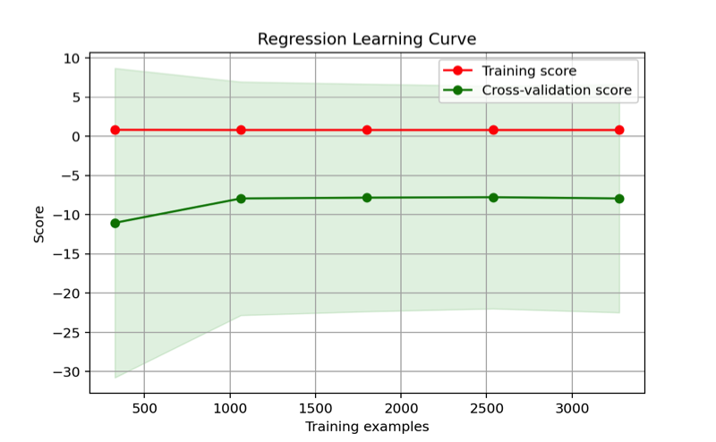

```python
# Regression Learning Curve
import matplotlib.pyplot as plt
import scikitplot as skplt

skplt.estimators.plot_learning_curve(LinearRegression(), predictor_vars, response_var,
                                     cv =7, shuffle =True, scoring ="r2", n_jobs =-1,
                                     figsize =(6,4), title_fontsize ="large", text_fontsize ="medium",
                                     title ="Regression Learning Curve")
plt.show()
```

## Model 2

### With year and sex removed

```python
# remove `year` and `sex` from next model
hb_mortality_reduced_further = hb_mortality_reduced.drop(columns = ['year', 'sex_Males'])
```

```python
# set our response array for new model
response_variable = hb_mortality_reduced_further['number_of_deaths']
# put our predictors in a data frame
predictor_variables = hb_mortality_reduced_further.drop(columns = 'number_of_deaths')
```

```python
# create train / test split new model
from sklearn.model_selection import train_test_split

mortality_predict_train, mortality_predict_test, mortality_respon_train, mortality_respon_test = (
    train_test_split(
        predictor_variables,
        response_variable,
        test_size = 0.1
    )
)
```

```python
# define model using train data
from sklearn.linear_model import LinearRegression

mortality_model_2 = LinearRegression()

mortality_model_2.fit(mortality_predict_train, mortality_respon_train)
```

```
LinearRegression()
```

```python
# check r-squared value of current model
from sklearn.model_selection import cross_val_score

mortality_model_2.score(mortality_predict_train, mortality_respon_train)
```

```
0.7858480366273068
```

```python
# r-squared scores for each fold
scores = cross_val_score(
    mortality_model_2, mortality_predict_train, mortality_respon_train, scoring='r2', cv=10
)
scores
```

```
array([0.76621809, 0.77204976, 0.79988364, 0.8064625 , 0.75787909,
       0.81660272, 0.76280457, 0.79112819, 0.73790896, 0.82083772])
```

```python
import numpy as np

print(mortality_model_2.score(mortality_predict_train, mortality_respon_train))
```

```
0.7858480366273068
```

```python
# mean score of all models
print(np.mean(scores))
```

```
0.783177523913638
```

```python
# feature importance by matching predictors to coefficients in a df
pd.DataFrame({
    'Variable':predictor_variables.columns,
    'Coefficients':mortality_model_2.coef_
})
```

```
                              Variable  Coefficients
0                           crude_rate      0.633864
1                                 easr     -0.429990
2                        hbr_S08000016    -14.920138
3                        hbr_S08000017    -11.950711
4                        hbr_S08000019     -5.121467
5                        hbr_S08000020      5.416854
6                        hbr_S08000022     -4.034405
7                        hbr_S08000024     13.528035
8                        hbr_S08000025     -2.012203
9                        hbr_S08000026     -2.097039
10                       hbr_S08000028     -1.164209
11                       hbr_S08000029     -2.598354
12                       hbr_S08000030     -0.001614
13                       hbr_S08000031     35.232881
14                       hbr_S08000032     12.201200
15               age_group_45-64 years      3.806583
16               age_group_65-74 years      1.771150
17              age_group_75plus years      4.815748
18             age_group_under75 years     17.100447
19                    diagnosis_Stroke     -6.384424
20  diagnosis_Subarachnoid Haemorrhage    -10.568751
```

```python
import statsmodels.api as sm

# add in the constant to the data
predictor_variables = sm.add_constant(predictor_variables)
predictor_variables.head()
```

```
   const  crude_rate  ...  diagnosis_Stroke  diagnosis_Subarachnoid Haemorrhage
0    1.0    0.000000  ...                 0                                   0
1    1.0    1.020346  ...                 0                                   0
2    1.0   19.117535  ...                 0                                   0
3    1.0   15.981249  ...                 0                                   0
4    1.0  133.475707  ...                 0                                   0

[5 rows x 22 columns]
```

```python
# model summary using statsmodels
sm_model_2 = sm.OLS(response_variable, predictor_variables).fit()
print(sm_model_2.summary())
```

```
                            OLS Regression Results
==============================================================================
Dep. Variable:       number_of_deaths   R-squared:                       0.791
Model:                            OLS   Adj. R-squared:                  0.790
Method:                 Least Squares   F-statistic:                     685.4
Date:                Tue, 07 Jun 2022   Prob (F-statistic):               0.00
Time:                        08:50:24   Log-Likelihood:                -17032.
No. Observations:                3822   AIC:                         3.411e+04
Df Residuals:                    3800   BIC:                         3.425e+04
Df Model:                          21
Covariance Type:            nonrobust
======================================================================================================
                                         coef    std err          t      P>|t|      [0.025      0.975]
------------------------------------------------------------------------------------------------------
const                                  4.7857      1.475      3.244      0.001       1.893       7.678
crude_rate                             0.6466      0.020     32.980      0.000       0.608       0.685
easr                                  -0.4428      0.019    -23.509      0.000      -0.480      -0.406
hbr_S08000016                        -14.4754      1.708     -8.476      0.000     -17.824     -11.127
hbr_S08000017                        -11.8157      1.708     -6.919      0.000     -15.164      -8.468
hbr_S08000019                         -6.4432      1.708     -3.773      0.000      -9.791      -3.095
hbr_S08000020                          5.1059      1.708      2.989      0.003       1.757       8.455
hbr_S08000022                         -3.9068      1.708     -2.288      0.022      -7.255      -0.558
hbr_S08000024                         14.3739      1.709      8.413      0.000      11.024      17.724
hbr_S08000025                         -2.0422      1.990     -1.026      0.305      -5.944       1.859
hbr_S08000026                         -2.4065      1.952     -1.233      0.218      -6.234       1.421
hbr_S08000028                         -1.3624      2.083     -0.654      0.513      -5.447       2.722
hbr_S08000029                         -2.9214      1.708     -1.711      0.087      -6.270       0.427
hbr_S08000030                         -0.1599      1.709     -0.094      0.925      -3.510       3.190
hbr_S08000031                         34.5137      1.708     20.209      0.000      31.165      37.862
hbr_S08000032                         12.2203      1.708      7.156      0.000       8.872      15.568
age_group_45-64 years                  3.7970      1.044      3.637      0.000       1.750       5.844
age_group_65-74 years                  1.6132      1.059      1.523      0.128      -0.464       3.690
age_group_75plus years                 4.6468      1.467      3.169      0.002       1.772       7.522
age_group_under75 years               16.9678      1.066     15.922      0.000      14.878      19.057
diagnosis_Stroke                      -6.1170      0.866     -7.062      0.000      -7.815      -4.419
diagnosis_Subarachnoid Haemorrhage   -10.3387      0.942    -10.976      0.000     -12.186      -8.492
==============================================================================
Omnibus:                     2964.891   Durbin-Watson:                   1.267
Prob(Omnibus):                  0.000   Jarque-Bera (JB):           310318.308
Skew:                           2.987   Prob(JB):                         0.00
Kurtosis:                      46.737   Cond. No.                     4.17e+03
==============================================================================

Notes:
[1] Standard Errors assume that the covariance matrix of the errors is correctly specified.
[2] The condition number is large, 4.17e+03. This might indicate that there are
strong multicollinearity or other numerical problems.
```

```python
# model score on test data
mortality_model_2.score(mortality_predict_test, mortality_respon_test)
```

```
0.8378803494185005
```

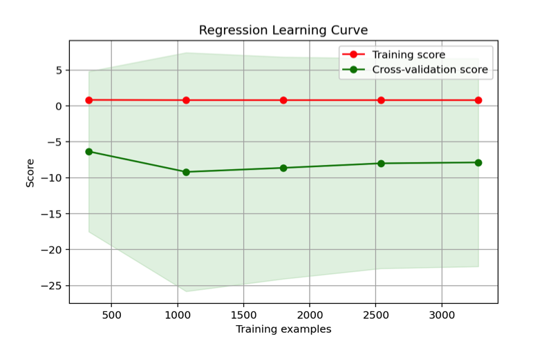

```python
# Regression Learning Curve
import matplotlib.pyplot as plt
import scikitplot as skplt

skplt.estimators.plot_learning_curve(LinearRegression(), predictor_variables, response_variable,
                                     cv =7, shuffle =True, scoring ="r2", n_jobs =-1,
                                     figsize =(6,4), title_fontsize ="large", text_fontsize ="medium",
                                     title ="Regression Learning Curve")
plt.show()
```

## Diagnostic Plots

```python
#first calculate the residuals
residuals = sm_model_2.fittedvalues - response_variable
```

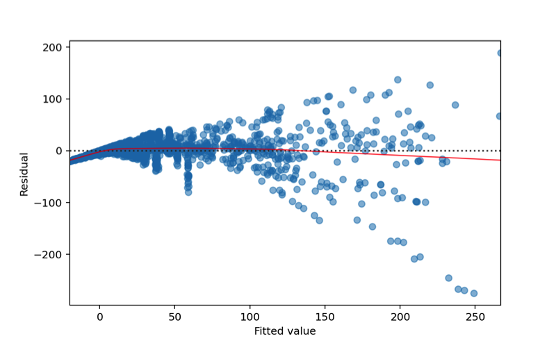

```python
import seaborn as sns
import matplotlib.pyplot as plt

sns.residplot(x = sm_model_2.fittedvalues, y = residuals,
                          lowess = True,
                          scatter_kws = {'alpha': 0.5},
                          line_kws = {'color': 'red', 'lw': 1, 'alpha': 0.8})
plt.xlabel("Fitted value")
plt.ylabel("Residual")
plt.show()
```

**Interpretation**

The line is almost horizontal and hovers around zero, which is good. However, the residuals do fan out for larger fitted values which means this model may not be the best at explaining all trends in our data.

### Normal QQ Plot

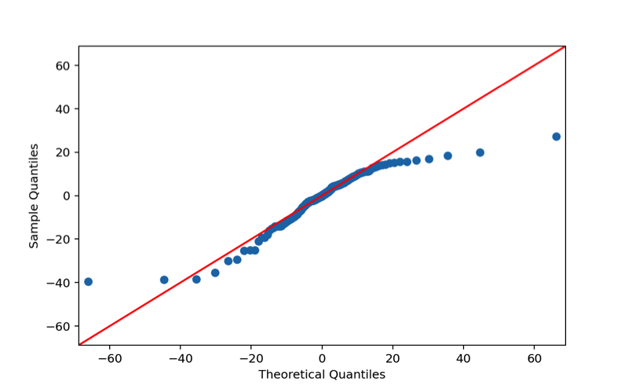

```python
plt.close()
import scipy.stats as stats

sm.qqplot(residuals, dist=stats.t, fit=True, line='45')
plt.show()
```

**Interpretation**

These look okay, generally follows our normal line for the main part.

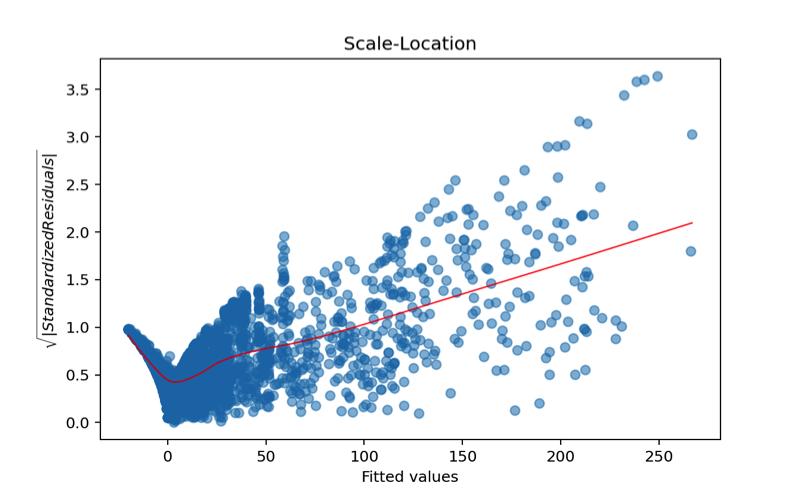

```python
plt.close()
# model values
model_fitted_y = sm_model_2.fittedvalues
# model residuals
model_residuals = sm_model_2.resid
# normalized residuals
model_norm_residuals = sm_model_2.get_influence().resid_studentized_internal
# absolute squared normalized residuals
model_norm_residuals_abs_sqrt = np.sqrt(np.abs(model_norm_residuals))
# absolute residuals
model_abs_resid = np.abs(model_residuals)

plot_lm_3 = plt.figure()
  plt.scatter(model_fitted_y, model_norm_residuals_abs_sqrt, alpha=0.5);
  sns.regplot(model_fitted_y, model_norm_residuals_abs_sqrt,
              scatter=False,
              ci=False,
              lowess=True,
              line_kws={'color': 'red', 'lw': 1, 'alpha': 0.8});
  plot_lm_3.axes[0].set_title('Scale-Location')
  plot_lm_3.axes[0].set_xlabel('Fitted values')
  plot_lm_3.axes[0].set_ylabel('$\sqrt{|Standardized Residuals|}$')
  plt.show()
```

**Interpretation**

Not great, line is in a loose ‘v’ shape, not what we want here. Shows that our error increases for larger fitted values.

**Model Presentation Notes**

What preds were sig, what were not interpretation of the coefficients, one numeric one cat if possible nice simple table of p-values